# Automatic Exploratory Data Analysis Tools in R - an Overview

Mateusz Staniak

12 - 03 - 2019

# 1 Introduction

With autoML tools like h2o Driverless AI or autoKeras, building predictive models is becoming easier and faster. But the first step in every Data Science project is understanding the particular dataset and its patterns. It usually referred to as Exploratory Data Analysis. This part of the analysis is crucial, but also time consuming, so it is tempting to try to automate it. This report is a summary of the existing R tools for automatic (or fast) EDA.

# 2 Automatic EDA Tasks

EDA tools have multiple possible goals and most of the tools only try to address some of them.

- Whole dataset summaries: provide information about sample size, number of variables and their types, possible relationships between several datasets and meta-data such amount of disk space used.
- Data validity: perform checks related to missing data and atypical values.
- Univariate summaries: depends on the variable type. For numerical variables, usually typical descriptive statistics such as centrality and dispersion measures, for categorical data, unique levels, and associated counts.
- Bivariate summaries: present simple relationships, either between one variable of interest and all other variables (contingency tables, scatter plots, survival curves, plots of distribution (boxplots, histograms, bar plots) by values of a variable), all pairs of variables (correlation matrices and plots) or chosen pairs of variables.
- Feature engineering: make variables more suitable for modeling. This includes PCA and other dimension reduction techniques, merging levels of categorical variables, transforming numerical variables (for example Box-Cox transformation).
- Data visualization: find visual insight into the data. This task is particularly challenging when the dataset is high dimensional.
- Quick reporting: create a report based on the above points.

# 3 Overview of R Tools for autoEDA

In this section, eight R packages are shortly summarized. One of them is only available on GitHub (`autoEDA`), the rest is on CRAN. The list is not exhaustive, but these are the most matured general-purpose packages. Other libraries exist, for example, `RBioPlot` which was written specifically for molecular biology data.

## 3.1 dataMaid

The `dataMaid` package has two central functions: the `check` function, which performs checks of data consistency and validity, and `makeDataReport`, which automatically creates a report (in PDF, DOCX or HTML format). The goal is to detect unusual (outliers, anomalies, incorrectly encoded) and missing values. The report contains whole dataset summary (variables and their types, number of missing values and if a problem was detected) and summaries (plot of the distribution and some descriptive statistic) for each variable separately.

`dataMaid` is on [CRAN](https://cran.r-project.org/package=dataMaid). A [vignette](https://cran.r-project.org/web/packages/dataMaid/vignettes/extending_dataMaid.html) explains how to manually define new checks and summaries. The R output below is an example of `dataMaid` summary and checks.

```r
dataMaid::summarize(select(recid_small, age, race))
```

```
## $age
## $age$variableType
## Variable type: numeric
## $age$countMissing
## Number of missing obs.: 0 (0 %)
## $age$uniqueValues
## Number of unique values: 65
## $age$centralValue
## Median: 31
## $age$quartiles
## 1st and 3rd quartiles: 25; 42
## $age$minMax
## Min. and max.: 18; 96
##
## $race
## $race$variableType
## Variable type: factor
## $race$countMissing
## Number of missing obs.: 0 (0 %)
## $race$uniqueValues
## Number of unique values: 6
## $race$centralValue
## Mode: "African-American"
## $race$refCat
## Reference category: African-American
```

```r
dataMaid::check(select(recid_small, age, race))
```

```
## $age
## $age$identifyMissing
## No problems found.
## $age$identifyOutliers
## Note that the following possible outlier values were detected: 18.
##
## $race
## $race$identifyMissing
## No problems found.
## $race$identifyWhitespace
## No problems found.
## $race$identifyLoners
## No problems found.
## $race$identifyCaseIssues
## No problems found.
## $race$identifyNums
## No problems found.
```

## 3.2 xray

The `xray` package offers three functions for the analysis of data prior to statistical modeling:

- detecting anomalies (missing data, zero values, blank strings, and infinite numbers),
- drawing (through histograms and bar plots) and printing (through quantile tables) univariate distributions of each variable,
- drawing plots of variables over time (for a specified time variable). Plots can be saved to png images.

The package can be found on [CRAN](https://cran.r-project.org/package=xray). Examples are presented in the [GitHub readme](https://github.com/sicarul/xray).

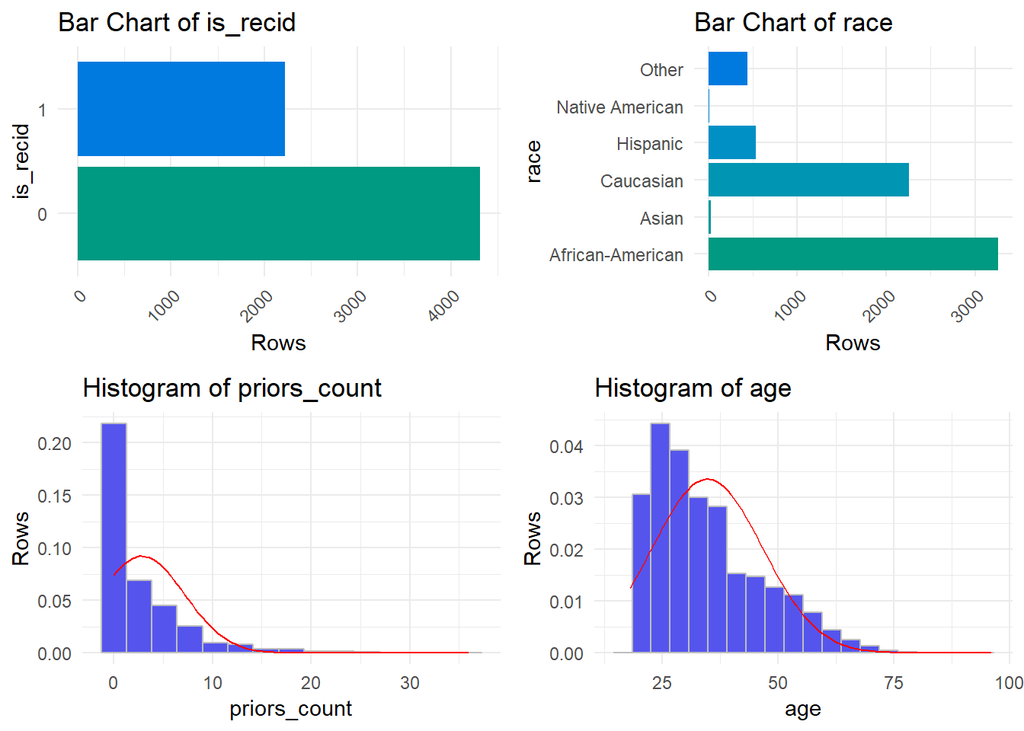

Example xray output

| Variable | p_1 | p_10 | p_25 | p_50 | p_75 | p_90 | p_99 |
| --- | --- | --- | --- | --- | --- | --- | --- |
| priors_count | 0 | 0 | 0 | 1 | 4 | 8 | 21 |
| age | 20 | 22 | 25 | 31 | 42 | 53 | 67 |

```r
xray::distributions(recid_small, charts = T) %>%
  kable()
```

## 3.3 visdat

The package `visdat` is maintained by rOpenSci. It consists of 6 functions that help visualize:

- variables types and missing data,
- types of each value in each column,
- clusters of missing values,
- differences between the two datasets,
- where given conditions are satisfied in the data,
- correlation matrix for the numerical variables. Each of these functions returns a single `ggplot2` plot that shows a rectangular representation of the dataset.

`visdat` is on [CRAN](https://cran.r-project.org/package=visdat). Example can be found in the [vignette](https://cran.mtu.edu/web/packages/visdat/vignettes/using_visdat.html).

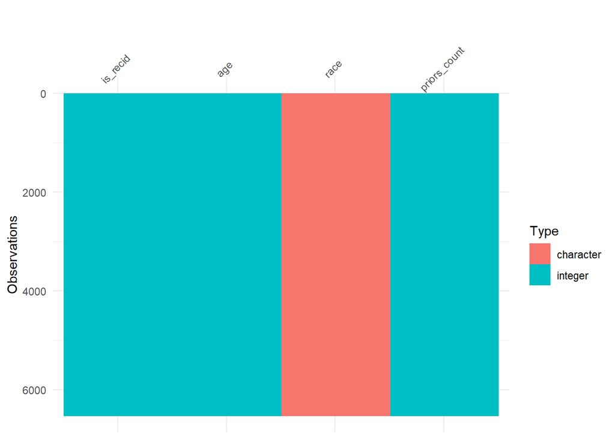

Example visdat output.

```r
visdat::vis_guess(recid_small)
```

## 3.4 dlookr

The `dlookr` package provides tools for 3 types of analysis: data diagnosis (correctness, missing values, and outliers detection), exploratory data analysis, feature engineering (imputation, dichotomization, a transformation of continuous features). It can also automatically generate a pdf report for all these analyses.

For data diagnosis, types of variables are reported along with counts of missing values and unique values. Variables with a low proportion of unique values are described separately. All the typical descriptive statistics are provided for each variable. Outliers are detected and distributions of variables before and after outlier removal are plotted.

In the EDA report, descriptive statistics are presented along with normality tests and a histogram of variables and their transformation that reduce skewness (logarithm and root square). Correlation plots are shown for numerical variables. If the target variable is specified, plots that show the relationship between the target and each predictor are also included.

Transformation report compares descriptive statistics and plots for each variable before and after imputation, skewness-removing transformation and binning.

The package in on [CRAN](https://cran.r-project.org/package=dlookr) and a dedicated vignette explains each of the main functionalities.

```r
dlookr::diagnose(recid) %>%
  kable(caption = "Example dlookr output (truncated).") %>%
  kable_styling(full_width = FALSE)
```

Example dlookr output (truncated).

| variables | types | missing_count | missing_percent | unique_count | unique_rate |
| --- | --- | --- | --- | --- | --- |
| sex | character | 0 | 0.0000000 | 2 | 0.0003060 |
| age | numeric | 0 | 0.0000000 | 65 | 0.0099434 |
| race | factor | 0 | 0.0000000 | 6 | 0.0009179 |
| juv_fel_count | numeric | 0 | 0.0000000 | 11 | 0.0016827 |
| juv_misd_count | numeric | 0 | 0.0000000 | 10 | 0.0015298 |
| juv_other_count | numeric | 0 | 0.0000000 | 11 | 0.0016827 |
| priors_count | numeric | 0 | 0.0000000 | 33 | 0.0050482 |
| c_offense_date | Date | 849 | 12.9876090 | 751 | 0.1148845 |
| c_arrest_date | character | 5688 | 87.0123910 | 475 | 0.0726633 |
| c_charge_degree | character | 0 | 0.0000000 | 12 | 0.0018357 |
| c_charge_desc | character | 4 | 0.0611901 | 387 | 0.0592015 |
| is_recid | factor | 0 | 0.0000000 | 2 | 0.0003060 |
| jail_days | numeric | 0 | 0.0000000 | 384 | 0.0587425 |
| age_at_offense | numeric | 849 | 12.9876090 | 4523 | 0.6919076 |

## 3.5 DataExplorer

`DataExplorer` is a new package that helps automatize EDA and simple feature engineering. It can also generate a report with data summaries. It has functions for:

- whole dataset summary (dimensions, types of variables, missing values etc),
- missing values visualization (percentage of missingness in each column),
- plotting distributions of variables (numerical and categorical variables separately),
- QQ Plots,
- plotting correlation matrices,
- visualizing PCA results,
- plotting relationships between the target variable and predictors (scatterplots and boxplots),
- replacing missing values by a constant,
- grouping sparse categories,
- creating dummy variables and dropping features. The automatic report can be customized. By default, it consists of all the above points except for feature engineering.

This package is on [CRAN](https://cran.r-project.org/package=DataExplorer) where a introductory [vignette](https://cran.r-project.org/web/packages/DataExplorer/vignettes/dataexplorer-intro.html) can be found.

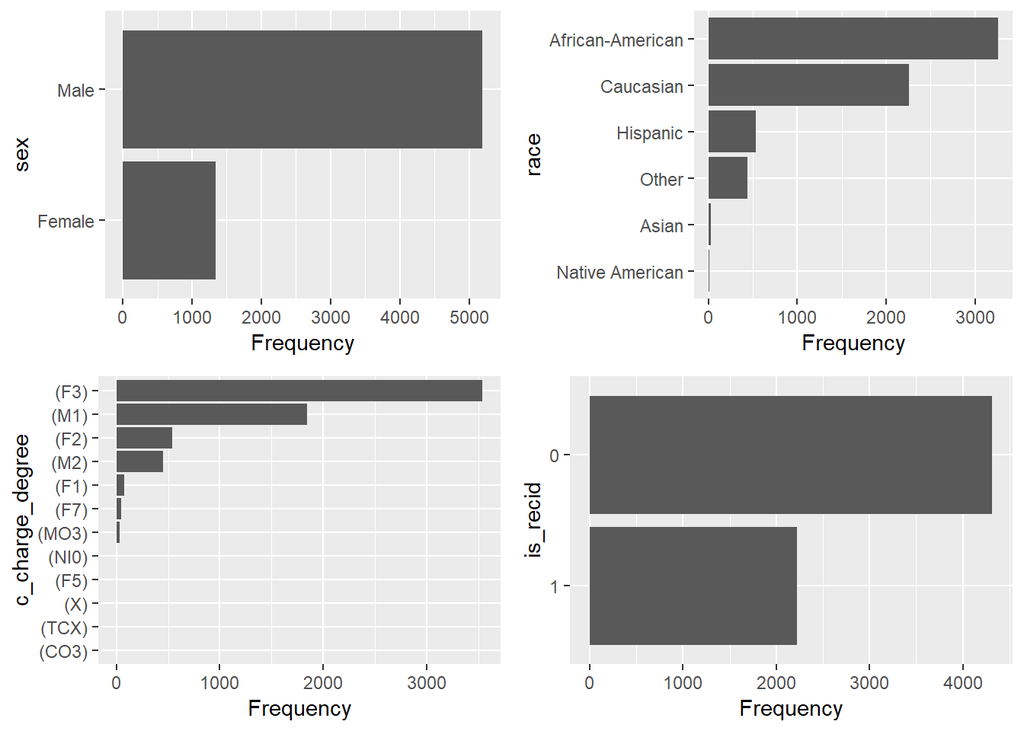

Example DataExplorer output.

```r
plot_bar(recid)
```

## 3.6 funModeling

The package `funModeling` is a reach set of tools for EDA connected to the book Data Science Live Book -Open Source- (2017). These tools include

- dataset summary,
- plots and descriptive statistics for categorical and numerical variables,
- correlation analysis (classical and based on information theory),
- plots of distribution of target variables vs predictors (bar plots, boxplots, histograms),
- quantitative analysis for binary target variables,
- different methods of discretization,
- variable scaling,
- outlier treatment,
- gain and lift curves.

The package is on [CRAN](https://cran.r-project.org/package=funModeling) and has an exhaustive [introduction vignette](https://cran.r-project.org/web/packages/funModeling/vignettes/funModeling_quickstart.html).

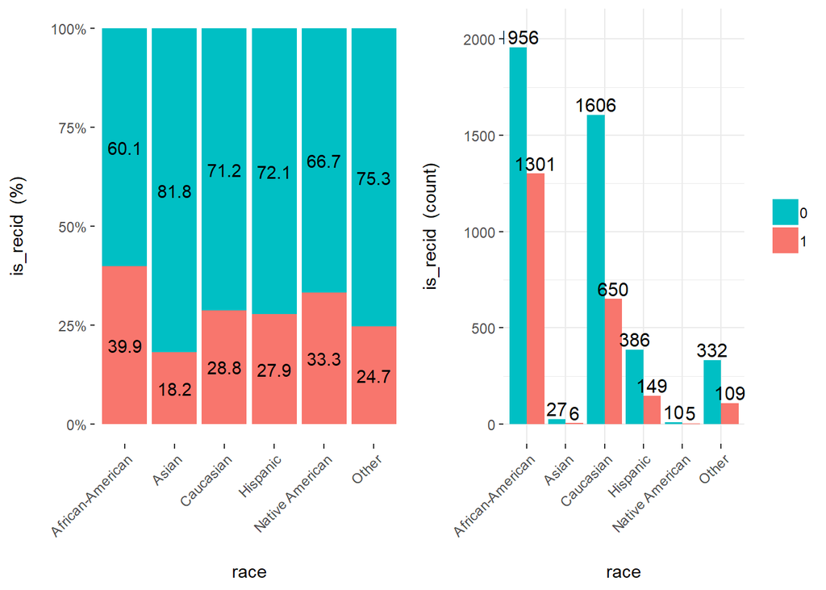

Example funModeling output.

```r
funModeling::cross_plot(recid_small, "race", "is_recid")
```

## 3.7 autoEDA

`autoEDA` package is a GitHub-based tool for univariate and bivariate visualizations. It can also generate a pdf report with the plots of distributions of predictors grouped by outcome variable or distribution of outcome by predictors.

The package can be found on [Xander Horn’s GitHub](https://github.com/XanderHorn/autoEDA) and a short article is on [LinkedIn](https://www.linkedin.com/pulse/automated-exploratory-data-analysis-r-xander-horn/).

```r
autoeda_tbl <- autoEDA::dataOverview(recid_small)
colnames(autoeda_tbl) <- stringr::str_trunc(colnames(autoeda_tbl), 10, ellipsis = "")

kable(autoeda_tbl[, 1:7], caption = "Example autoEDA output (truncated).") %>%
  kable_styling(full_width = F)
```

Example autoEDA output (truncated).

| Feature | Observatio | FeatureCla | FeatureTyp | Percentage | Percentage.1 | ConstantFe |
| --- | --- | --- | --- | --- | --- | --- |
| is_recid | 6537 | factor | Categorical | 0 | 0.03 | No |
| age | 6537 | numeric | Continuous | 0 | 0.99 | No |
| race | 6537 | factor | Categorical | 0 | 0.09 | No |
| priors_count | 6537 | numeric | Continuous | 0 | 0.50 | No |

## 3.8 arsenal

The `arsenal` package is a set of 5 tools for data exploration:

- descriptive statistics by levels of a target variable (like Table 1), also for paired observation (for example longitudinal data),
- comparing data frames,
- frequency tables for multiple categorical variables,
- fitting and summarizing simple statistical models (linear regression, Cox model etc). Results of each function can be saved to a short report.

`arsenal` is on [CRAN](https://cran.r-project.org/web/packages/arsenal/index.html) and includes a vignette for each of the functions.

```r
summary(arsenal::tableby(is_recid ~., data = recid_small)) %>%
  kable(caption = "Example arsenal output.") %>%
  kable_styling(full_width = FALSE)
```

Example arsenal output.

|  | 0 (N=4317) | 1 (N=2220) | Total (N=6537) | p value |
| --- | --- | --- | --- | --- |
| **age** |  |  |  | < 0.001 |
| &nbsp;&nbsp;&nbsp;Mean (SD) | 36.020 (12.276) | 32.075 (10.594) | 34.681 (11.879) |  |
| &nbsp;&nbsp;&nbsp;Range | 18.000 - 83.000 | 18.000 - 96.000 | 18.000 - 96.000 |  |
| **race** |  |  |  | < 0.001 |
| &nbsp;&nbsp;&nbsp;African-American | 1956 (45.3%) | 1301 (58.6%) | 3257 (49.8%) |  |
| &nbsp;&nbsp;&nbsp;Asian | 27 (0.6%) | 6 (0.3%) | 33 (0.5%) |  |
| &nbsp;&nbsp;&nbsp;Caucasian | 1606 (37.2%) | 650 (29.3%) | 2256 (34.5%) |  |
| &nbsp;&nbsp;&nbsp;Hispanic | 386 (8.9%) | 149 (6.7%) | 535 (8.2%) |  |
| &nbsp;&nbsp;&nbsp;Native American | 10 (0.2%) | 5 (0.2%) | 15 (0.2%) |  |
| &nbsp;&nbsp;&nbsp;Other | 332 (7.7%) | 109 (4.9%) | 441 (6.7%) |  |
| **priors_count** |  |  |  | < 0.001 |
| &nbsp;&nbsp;&nbsp;Mean (SD) | 1.999 (3.408) | 4.483 (5.328) | 2.842 (4.324) |  |
| &nbsp;&nbsp;&nbsp;Range | 0.000 - 33.000 | 0.000 - 36.000 | 0.000 - 36.000 |  |

# 4 Feature Comparison

In this section, I will compare how different packages address autoEDA tasks. For a quick overview of package features, see the table below.

```r
comparison_table %>%
  rename(task = X1, feature = X2) %>%
  mutate_if(is.numeric, function(x) ifelse(x == 1, "x", "")) %>%
knitr::kable() %>%
  kable_styling(full_width = F)
```

| task | feature | DataExplorer | dataMaid | funModeling | visdat | arsenal | xray | autoEDA | dlookr |
| --- | --- | --- | --- | --- | --- | --- | --- | --- | --- |
| Whole dataset | Variable types | x | x | x | x |  |  | x | x |
| Whole dataset | Dataset size | x | x | x | x |  |  | x | x |
| Whole dataset | Other info | x |  |  | x |  |  |  |  |
| Whole dataset | Compare two datasets |  |  |  | x | x |  |  |  |
| Data validity | Missing values | x | x | x | x |  | x | x | x |
| Data validity | Redundant columns |  | x | x | x |  |  | x | x |
| Data validity | Outliers |  | x | x |  |  |  | x | x |
| Data validity | Atypical values |  | x |  |  |  | x |  |  |
| Data validity | Level encoding |  | x |  |  |  |  |  |  |
| Univariate analysis | Descriptive statistics |  | x | x |  |  | x | x | x |
| Univariate analysis | Histograms | x | x | x |  |  |  | x | x |
| Univariate analysis | Boxplots | x |  |  |  |  |  |  |  |
| Univariate analysis | Bar plots | x | x | x |  |  |  | x | x |
| Univariate analysis | QQ plots | x |  |  |  |  |  |  | x |
| Bivariate analysis | Descriptive statistics |  |  |  |  |  |  |  | x |
| Bivariate analysis | Correlation matrix | x |  |  |  |  |  |  | x |
| Bivariate analysis | 1 vs each correlation |  |  | x |  |  |  | x |  |
| Bivariate analysis | Time-dependency |  |  |  |  | x | x |  |  |
| Bivariate analysis | Bar plots by target | x |  | x |  |  |  | x | x |
| Bivariate analysis | Histograms by target |  |  | x |  |  |  | x | x |
| Bivariate analysis | Scatter plots | x |  |  |  |  |  |  |  |
| Bivariate analysis | Contigency tables |  |  |  |  | x |  |  | x |
| Bivariate analysis | Other stats. for factors |  |  | x |  |  |  |  |  |
| Multivariate analysis | PCA | x |  |  |  |  |  |  |  |
| Multivariate analysis | Stat. Models |  |  |  |  | x |  |  |  |
| Feature engineering | Imputation |  |  |  |  |  |  |  | x |
| Feature engineering | Scaling |  |  | x |  |  |  |  |  |
| Feature engineering | Skewness reduction |  |  |  |  |  |  |  | x |
| Feature engineering | Outlier treatment |  |  | x |  |  |  |  | x |
| Feature engineering | Binning (cont. vars) | x |  | x |  |  |  |  | x |
| Feature engineering | Merging factor levels | x |  |  |  |  |  |  |  |
| Quick reporting | PDF/html reports | x | x |  |  |  |  | x | x |
| Quick reporting | Saving plots/outputs |  |  | x |  | x | x |  |  |

## 4.1 Whole dataset summaries

`visdat` package offers the most original summaries of full dataset.

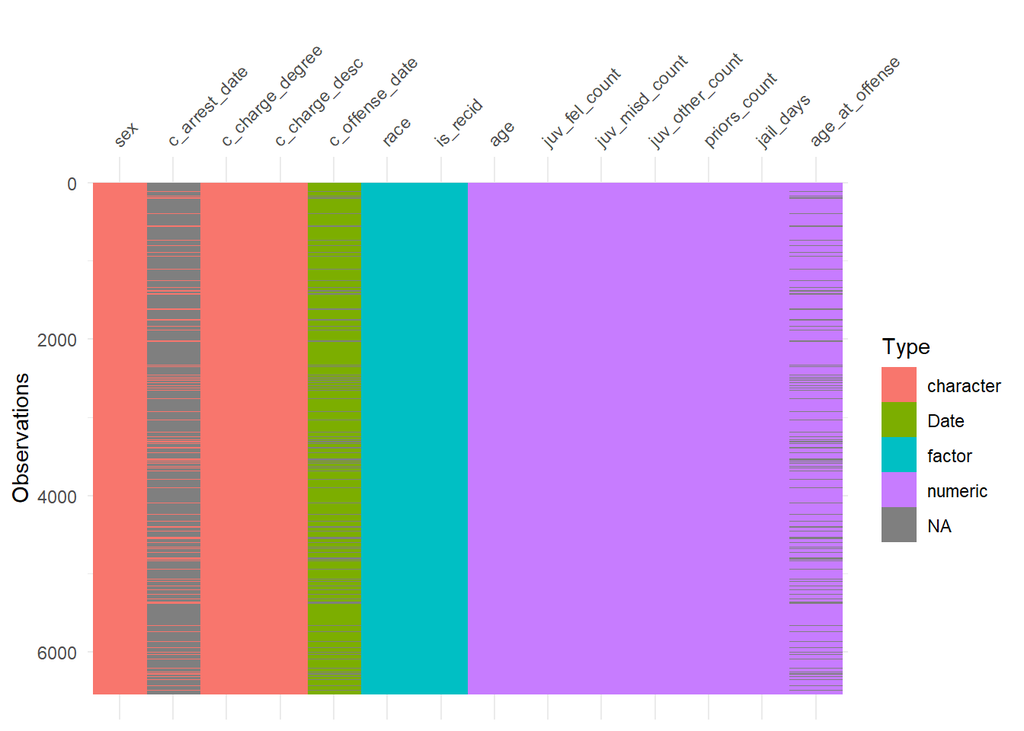

```r
visdat::vis_dat(recid)
```

The drawback of this approach is that it is not well suited for high dimensional data. But for a smaller number of variables, it gives a good overview of the dataset.

Most packages that provide a whole dataset summary take a similar approach and present names and types of variables, number of missing values and sometimes unique values or other statistics. This is true for `autoEDA` (`dataOverview` function), `dataMaid` (`makeDataReport` result), `funModeling` (`df_status` function) and `DataExplorer` (`introduce` function), which provides the information separately on two plots - one for dataset structure, one for missing data. The `dlookr` package provides summaries for numerical variables and categorical variables are presented only in the report, separately (`describe` function).

## 4.2 Data validity

Some packages offer automated checks for the data. This include at least outlier detection. The `dataMaid` package’s main purpose is to find inconsistencies and errors in the data. It finds possible outliers, missing values, low-frequency and possibly miscoded levels of factors. All this information can be summarized in a quality report. The `dlookr` package offers similar functionality. There are two main differences:

- the report does not contain possible miscoded factors,
- outlier analysis is supplemented with plots showing variable distribution before and after removing the outliers.

The analysis is rather simple, for example in zero-inflated variables non-zero values are treated as outliers (`dlookr`).

## 4.3 Univariate summaries

All the tools that support univariate analysis take a similar approach. For categorical variables, counts are reported and bar plots are presented, while histogram or boxplots and typical descriptive statistics (including quantiles, sometimes skewness) are used for continuous variables.

In `dataMaid` and `dlookr` packages, these plots are presented variable-by-variable in the report. In other packages (`dataExplorer`, `funModeling`) groups of plots are shown together (wall of histograms, a wall of bar plots). Notably, the `dlookr` reports skewness of variables and in case a skewed variable is found, it shows the distribution after some candidate transformations to reduce the skewness. This package also reports normality.

## 4.4 Bivariate summaries

The `funModeling` package only supports calculating correlations between variables and a specified target. `DataExplorer`, `vis_dat` and `DataExplorer` packages can plot correlation matrices. They differ in categorical variables treatment. Some packages require only numerical features (`vis_dat`). Interestingly, in `DataExplorer`, low-cardinality categorical features are converted to 0-1 variables and plotted alongside numerical variables.

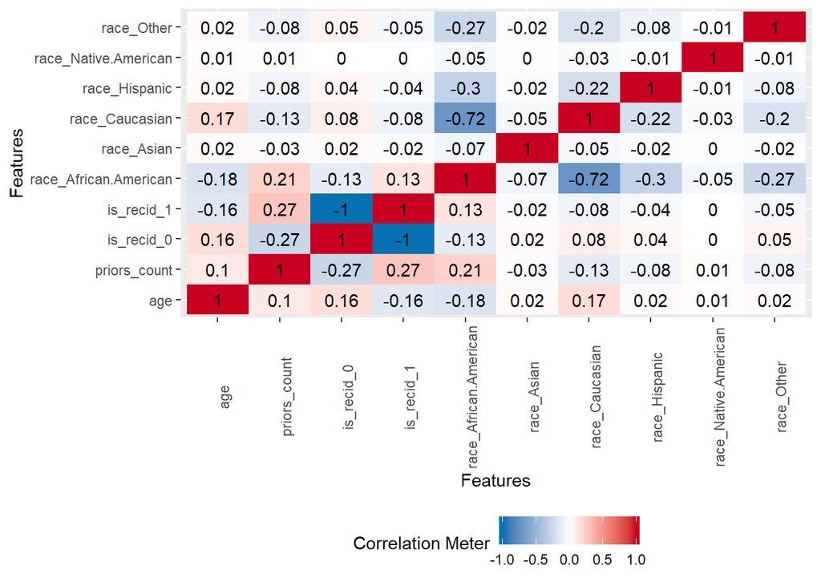

```r
DataExplorer::plot_correlation(recid_small)
```

The report from `autoEDA` package consists of a limited number of bar plots/boxplots with target variable as one of the dimensions. The `arsenal` package only presents variable summaries by levels of a chosen categorical variable. Similarly, in `DataExplorer`, `dlookr` and `funModeling`, scatter plots and boxplots with a specified target variable on one of the axis can be plotted. Additionally, `funModeling` and `dlookr` draw histograms/densities of continuous features by the target. The `funModeling` package also has unique options: drawing bar plots of discretized variables by the target and quantitative analysis for binary outcome based on representativeness and accuracy.

```r
knitr::kable(funModeling::categ_analysis(recid, "race", "is_recid")) %>%
  kable_styling(full_width = F)
```

| race | mean_target | sum_target | perc_target | q_rows | perc_rows |
| --- | --- | --- | --- | --- | --- |
| African-American | 0.399 | 1301 | 0.586 | 3257 | 0.498 |
| Native American | 0.333 | 5 | 0.002 | 15 | 0.002 |
| Caucasian | 0.288 | 650 | 0.293 | 2256 | 0.345 |
| Hispanic | 0.279 | 149 | 0.067 | 535 | 0.082 |
| Other | 0.247 | 109 | 0.049 | 441 | 0.067 |
| Asian | 0.182 | 6 | 0.003 | 33 | 0.005 |

## 4.5 Feature engineering

The `dataMaid` package assumes that every decision regarding the data should be made by the analyst and does not provide any tools for data manipulation after diagnosis. Most of the packages only provide exploration tools. Exceptions are `dlookr`, `funModeling` and `DataExplorer`. `DataExplorer` tools are limited to imputation by a constant, merging levels of factors and creating dummy variables.

The `dlookr` package can create a report that presents different possible transformations of features. Missing values can be imputed by mean/median/mode and distributions of variables before and after the procedure compared. The same is done for imputation of outliers. Logarithmic and root square transforms are proposed for skewed variables. Different methods of binning continuous variables are also presented, including Weight of the Evidence.

The `funModeling` package can perform discretization of a variable using an equal frequency criterion or gain ratio maximization. It can also scale variables to the interval [0, 1]. Outliers can be treated using the Tukey or Hampel method.

## 4.6 Data visualization

Data visualization is mostly limited to univariate and bivariate plots described above. Some original visualizations for the whole dataset are provided by `visdat` package. Currently, none of the packages perform visualization recommendation. Available plots are limited to standard uni- and bivariate graphics.

## 4.7 Quick reporting

`DataExplorer`, `dlookr` and `dataMaid` packages are capable of generating good quality reports. They consist of all (or most) possible outputs of the package which are organized either by variable (`dataMaid`, `dlookr`) or by type of variable (`DataExplorer`). `autoEDA` package generates a minimal report with bivariate plots. Example reports from these packages can be found in the `usecase/` directory. Packages `arsenal`, `funModeling` and `xray` have an option of saving outputs to files.

# 5 Summary

Undoubtedly, the presented have many advantages. Still, there are many open problems related to automated data exploration that could vastly improve them.

## 5.1 Strengths

- The packages `dlookr`, `dataMaid` and `DataExplorer` are capable of creating good quality reports.
- `DataExplorer` has very good visualizations for PCA.
- `DataExplorer` handles categorical variables on correlation plots by creating dummy features, which is a unique idea compared to other packages.
- The `visdat` package, while probably not the best choice for high dimensional data, features interesting take on initial whole dataset exploration.
- The `dlookr` package is capable of selecting skewed variables and proposing transformations.
- `dataMaid` is a good tool for finding problems in the data.
- For datasets with a moderate number of features, `DataExplorer`, `funModeling` and `dlookr` give a reasonable insight into variables distributions and simple relationships.

## 5.2 Weaknesses

- All the presented tools are likely to fail in typical situations with imperfect data. In particular, they are usually not robust to issues like zero-variance/constant variables (`dataExplorer` can’t generate a report in this case). Error messages in some cases not uninformative.
- In some situations, they lack flexibility. For example, in `DataExplorer` arguments can be passed to `cor` function, but not to `corrplot` function.
- In case of *walls* of histograms or bar plots, no selection is being done and no specific order is chosen to promote most interesting distributions. Moreover, for high-dimensional data or high-cardinality factors, the plots are unreadable or impractical. This is especially true for `DataExplorer` and `funModeling` functions (e.g. `cross_plot`), even though `DataExplorer` removes too large factors from the panels.
- Plots are limited to bivariate relationships, when exploring higher dimensional dependencies would be interesting (for example through colors and sizes).
- Support for time-varying variables and non-classical (not IID) problems such as survival analysis is limited or non-existent.
- Automated reports could be enriched by textual annotations and descriptions, either built from a simple template or from a generative model.
- Only one of the packages addresses the issue of skewed variables. Proposing transformations of continuous features (other than binning) could be also useful.
- Exploration based on simple statistical models (for example scatter plot smoothing) is not an option in any of the packages.
- None of the packages addresses issues such as multicollinearity.
- Missing data imputation more advanced than imputing a constant is delegated to other variables.
- Some of the above issues (lack of recommendations, not performing imputation or other transformation) result in the packages being not suitable for iterative work.